# Time to Inactivity: Survival Analysis of US Grocery Loyalty Households

Kaplan-Meier, log-rank tests and Cox proportional hazards (R validation layer) on the Complete Journey data

Author

Household churn and lifetime value project

Published

October 15, 2026

## Question, data and event definition

The Python models answer *who* is likely to be inactive in the 90 days after a cutoff. This report asks *when* households first go quiet and which early shopping behaviours are associated with that timing.

Data: the `completejourney` CC0 sample released by 84.51 (2,469 loyalty-card households, calendar year 2017, one retail chain). There is no subscription or cancellation record, so everything below is an **inactivity proxy**, not observed churn.

- **Event (lapse)**: the first gap between two shopping days longer than 90 days, starting at or after the landmark. A lapse is only confirmable if the 90-day gap fits inside the data, so households with no confirmable lapse are right-censored at `data_end - 90` days.
- **Time origin**: the first *observed* purchase. The panel starts on 2017-01-01, so this is **not** acquisition: households that already shopped before 2017 enter at their first 2017 purchase (left-censored tenure).
- **Landmark design**: baseline covariates are measured over the 28 days after the origin and households enter the risk set at origin + 28 days. Covariates never use follow-up information, which avoids immortal-time bias.
- **Exclusions** (counted, not hidden): households whose landmark falls after `data_end - 90` (no time at risk) and households that already lapsed before the landmark.
- Everything is an observational association. Nothing here is a causal effect of coupons or basket size.

```r
Sys.setenv(CHURN_CLV_ROOT = normalizePath(".."))
source("../R/survival_analysis.R", chdir = FALSE)
```

```r
library(knitr)
out <- file.path(root, "artifacts", "r_survival")
rd <- function(f) readr::read_csv(file.path(out, f), show_col_types = FALSE)
```

## Overall survival

2278 households analysed, 297 lapse events (13%), maximum follow-up 247 days after the landmark.

```r
kable(rd("km_overall.csv"), digits = 3, caption = "Kaplan-Meier: share of households without a 90-day lapse")
```

Kaplan-Meier: share of households without a 90-day lapse

| time | survival | lower | upper | n_risk |
| --- | --- | --- | --- | --- |
| 30 | 0.974 | 0.968 | 0.981 | 2210 |
| 60 | 0.955 | 0.947 | 0.964 | 2154 |
| 90 | 0.934 | 0.924 | 0.944 | 2094 |
| 120 | 0.919 | 0.908 | 0.930 | 2043 |
| 180 | 0.889 | 0.876 | 0.902 | 1907 |
| 240 | 0.867 | 0.853 | 0.881 | 1265 |

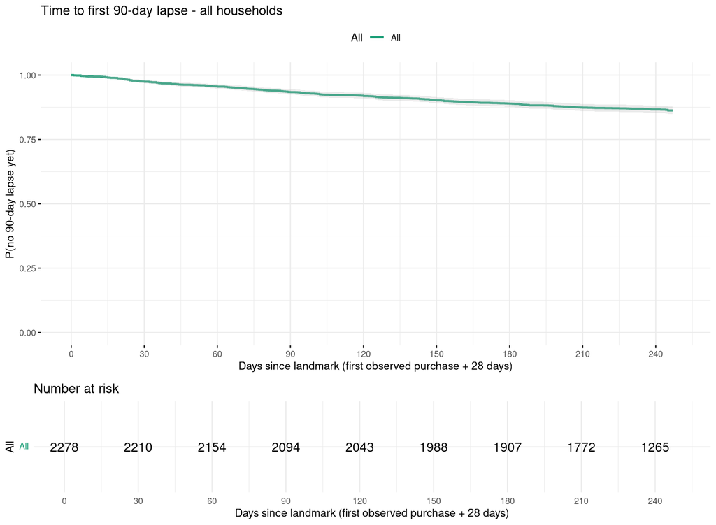

The curve is flat compared with a subscription business: most loyalty-card households keep shopping. The median time to lapse is not reached within the follow-up window, so we report survival at fixed horizons instead of a median.

## Segment comparisons (log-rank)

Tiers use quantile cut points of real values, so households with the same value always share a tier: trip tiers (T1/T2/T3) sizes: 995/668/615; trips per tier max: 3/6/27.

```r
kable(rd("logrank_tests.csv"), digits = 4, caption = "Log-rank tests")
```

Log-rank tests

| variable | chisq | df | p_value |
| --- | --- | --- | --- |
| trip_tier | 187.7406 | 2 | 0 |
| basket_tier | 36.8716 | 3 | 0 |
| coupon_user | 38.8429 | 1 | 0 |
| entry_group | 130.2005 | 2 | 0 |

**Baseline trips (tertiles)**

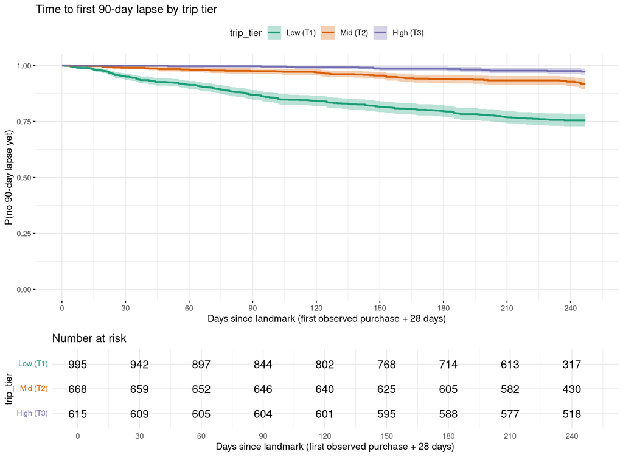

```r
kable(rd("km_by_trip_tier.csv"), digits = 3)
```

| strata | time | survival | n_risk |
| --- | --- | --- | --- |
| Low (T1) | 90 | 0.868 | 844 |
| Low (T1) | 180 | 0.795 | 714 |
| Mid (T2) | 90 | 0.974 | 646 |
| Mid (T2) | 180 | 0.939 | 605 |
| High (T3) | 90 | 0.997 | 604 |
| High (T3) | 180 | 0.985 | 588 |

**Baseline basket size (quartiles)**

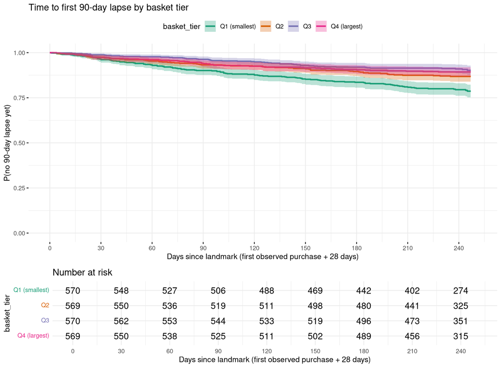

```r
kable(rd("km_by_basket_tier.csv"), digits = 3)
```

| strata | time | survival | n_risk |
| --- | --- | --- | --- |
| Q1 (smallest) | 90 | 0.901 | 506 |
| Q1 (smallest) | 180 | 0.836 | 442 |
| Q2 | 90 | 0.932 | 519 |
| Q2 | 180 | 0.896 | 480 |
| Q3 | 90 | 0.963 | 544 |
| Q3 | 180 | 0.920 | 496 |
| Q4 (largest) | 90 | 0.940 | 525 |
| Q4 (largest) | 180 | 0.905 | 489 |

**Coupon use in baseline window**

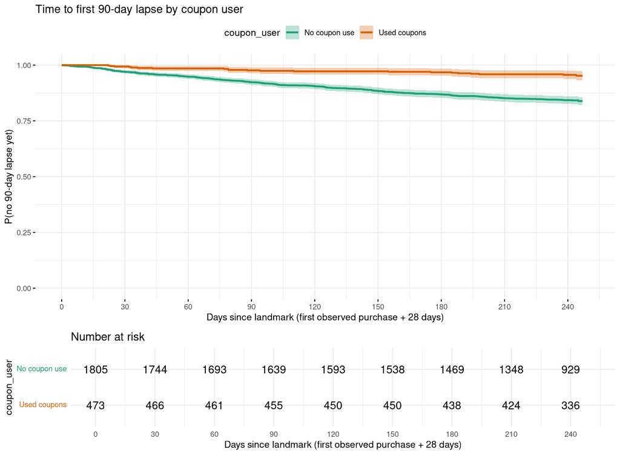

```r
kable(rd("km_by_coupon_user.csv"), digits = 3)
```

| strata | time | survival | n_risk |
| --- | --- | --- | --- |
| No coupon use | 90 | 0.923 | 1639 |
| No coupon use | 180 | 0.869 | 1469 |
| Used coupons | 90 | 0.977 | 455 |
| Used coupons | 180 | 0.968 | 438 |

**Entry month group**

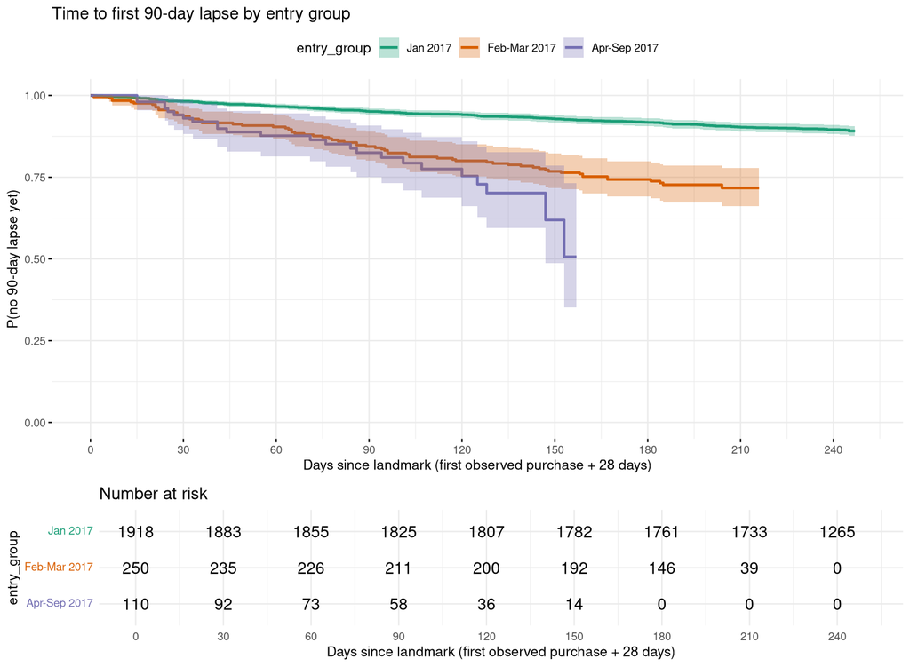

```r
kable(rd("km_by_entry_group.csv"), digits = 3)
```

| strata | time | survival | n_risk |
| --- | --- | --- | --- |
| Jan 2017 | 90 | 0.951 | 1825 |
| Jan 2017 | 180 | 0.918 | 1761 |
| Feb-Mar 2017 | 90 | 0.844 | 211 |
| Feb-Mar 2017 | 180 | 0.743 | 146 |
| Apr-Sep 2017 | 90 | 0.825 | 58 |

Entry month group is partly a data-window artifact: households that first appear after January are lighter shoppers (median 2 baseline trips versus 4 for January entrants), as a household that shopped weekly would usually have appeared in January. It is therefore used as an adjustment variable, not interpreted as a cohort effect.

## Cox proportional hazards

```r
kable(rd("cox_hazard_ratios.csv"), digits = 3, caption = "Hazard ratios (HR < 1 = slower lapse)")
```

Hazard ratios (HR < 1 = slower lapse)

| term | hr | lower95 | upper95 | p_value |
| --- | --- | --- | --- | --- |
| log_trips | 0.253 | 0.190 | 0.337 | 0.000 |
| log_basket | 0.802 | 0.710 | 0.906 | 0.000 |
| fresh_10pts | 0.945 | 0.895 | 0.997 | 0.039 |
| coupon_userUsed coupons | 0.563 | 0.355 | 0.893 | 0.015 |
| store_pattern2+ stores | 0.924 | 0.690 | 1.236 | 0.594 |
| entry_groupFeb-Mar 2017 | 1.723 | 1.290 | 2.303 | 0.000 |
| entry_groupApr-Sep 2017 | 2.710 | 1.764 | 4.162 | 0.000 |

Concordance: 0.775 (se 0.012).

### Proportional-hazards check (`cox.zph`)

```r
kable(rd("cox_zph.csv"), digits = 4)
```

| term | chisq | df | p_value |
| --- | --- | --- | --- |
| log_trips | 7.0209 | 1 | 0.0081 |
| log_basket | 0.4442 | 1 | 0.5051 |
| fresh_10pts | 0.4233 | 1 | 0.5153 |
| coupon_user | 0.0002 | 1 | 0.9893 |
| store_pattern | 1.0767 | 1 | 0.2994 |
| entry_group | 8.3566 | 2 | 0.0153 |
| GLOBAL | 18.9641 | 7 | 0.0083 |

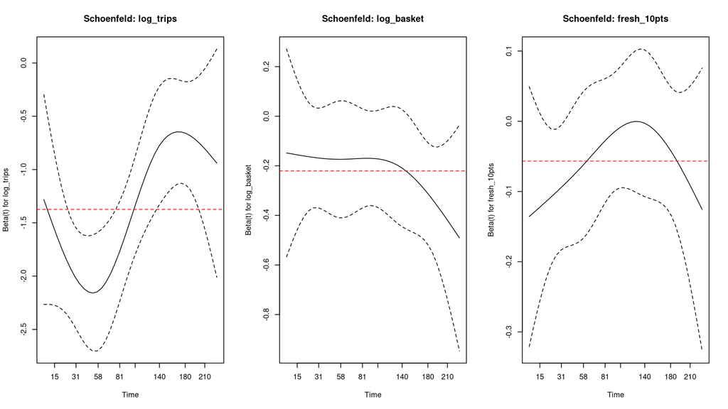

The global test rejects proportional hazards (p < 0.01): baseline trip frequency (`log_trips`) and the entry group both show time-varying effects (see the Schoenfeld plots). The model is therefore refitted **stratified** on entry group, which brings the global test closer to non-significance, but the `log_trips` violation remains. Its hazard ratio should be read as an *average* effect over follow-up, not a constant one.

```r
kable(rd("cox_stratified_hazard_ratios.csv"), digits = 3, caption = "Stratified Cox (strata = entry group)")
```

Stratified Cox (strata = entry group)

| term | hr | lower95 | upper95 | p_value |
| --- | --- | --- | --- | --- |
| log_trips | 0.253 | 0.190 | 0.337 | 0.000 |
| log_basket | 0.802 | 0.710 | 0.906 | 0.000 |
| fresh_10pts | 0.944 | 0.894 | 0.996 | 0.035 |
| coupon_userUsed coupons | 0.567 | 0.358 | 0.899 | 0.016 |
| store_pattern2+ stores | 0.923 | 0.690 | 1.235 | 0.589 |

```r
kable(rd("cox_stratified_zph.csv"), digits = 4, caption = "Stratified cox.zph")
```

Stratified cox.zph

| term | chisq | p_value |
| --- | --- | --- |
| log_trips | 8.5048 | 0.0035 |
| log_basket | 0.3103 | 0.5775 |
| fresh_10pts | 0.2904 | 0.5900 |
| coupon_user | 0.0063 | 0.9365 |
| store_pattern | 1.3311 | 0.2486 |
| GLOBAL | 10.2808 | 0.0677 |

## Sensitivity and limitations

```r
cat(tail(readLines(file.path(out, "summary.txt")), 2), sep = "\n")
```

```
Sensitivity (Jan-2017 entrants only, n=1918, events=203): HR log_trips = 0.232 (main stratified: 0.253)
Demographics subset: n=798 households with income and age, events=8 (of 2278 analysed)
```

- Lapse is a behavioural proxy; a household may return after 90 or more days (the event is “first lapse”, not permanent churn).
- One calendar year only: follow-up is at most about 8 months after the landmark and tenure before 2017 is unknown.
- Covariates are baseline-window only; the Python model uses time-varying behaviour.
- Demographics cover 801 of 2,469 households and those households are heavier shoppers, with very few lapse events (see the line above), so no demographic survival model is fitted.
- Results are associations, not causal effects of coupons, basket size or store pattern.